# SwathFinding

wkumler

August 6, 2019

Mass values in a mass spectrometer are collected in “swaths”. Finding these swaths of data collection is important when squaring MS data because then each data point can be assigned a single mz/rt value across different files.

However, these swaths are not equally spaced, but instead separated by a distance proportional to the mass of the molecule. Further, this separation is not linear with mass but instead has a gentle curve that appears to be best matched by second-order polynomials.

Swaths can be collapsed into peaks by histogramming the number of values found at a given m/z value. Histogram bins with a high count will be closer to the center of the swath, while histogram bins with low or zero count are found between swaths, as seen in the figure below.

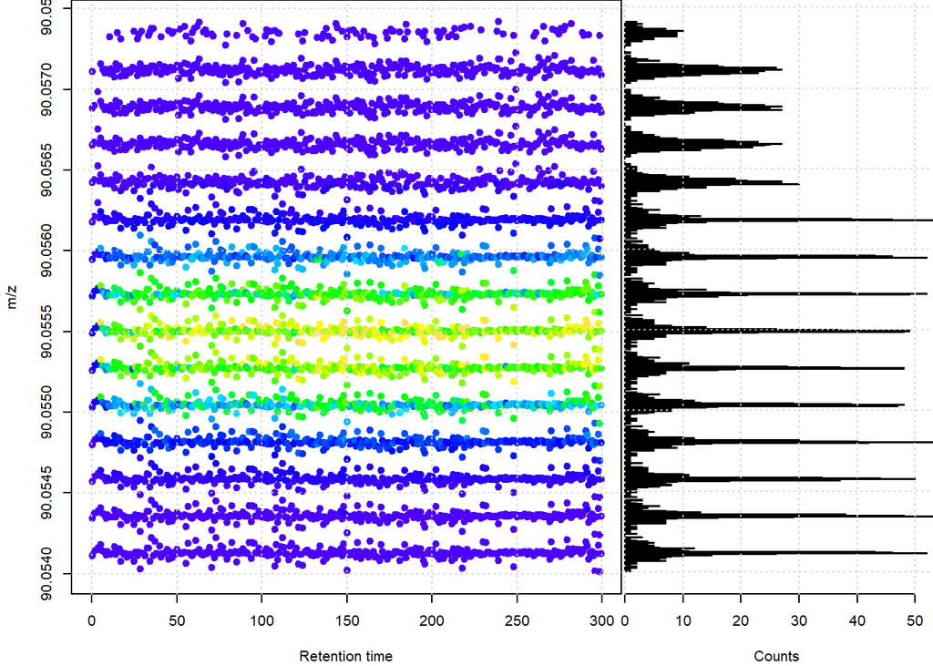

```r
#SwathFindingMiniData was created by filtering
# Z:/1_QEdata/Will/RectangulaRdata/positive/190715_Blk_KM1906U14-Blk_C.mzML
# to masses less than 120 m/z and retention times less than 300 s

simple_data <- readMSData("SwathFindingMiniData.mzML", centroided. = F, msLevel. = 1)

layout(matrix(c(1,1,2,1,1,2), byrow = T, nrow = 2))
par(mar=c(4.1, 4.1, 0, 0))
x <- simple_data %>%
  filterMz(c(90.054, 90.058)) %>%
  as("data.frame")
plot(x$rt, x$mz, main = "", pch = 19, xlab = "Retention time", ylab = "m/z",
     col = lattice:::level.colors(x$i, col.regions = topo.colors,
                                  at = lattice::do.breaks(range(x$i), nint = 256)))
grid()
par(mar=c(4.1, 0, 0, 0))
barplot(hist(x$mz, breaks = 1000, plot=F)$counts,
        axes = T, space = 0, horiz=TRUE, xlab="Counts", ylab="")
grid()
```

The swaths are fairly regular, so we’d like to find the “typical” distance between swaths and use that to slice our data into nice bins, each bin including one m/z swath. To do that, we apply some peakfinding software from MALDIquant to find the local maximum of each peak in the histogram and report the distance between the local maxima.

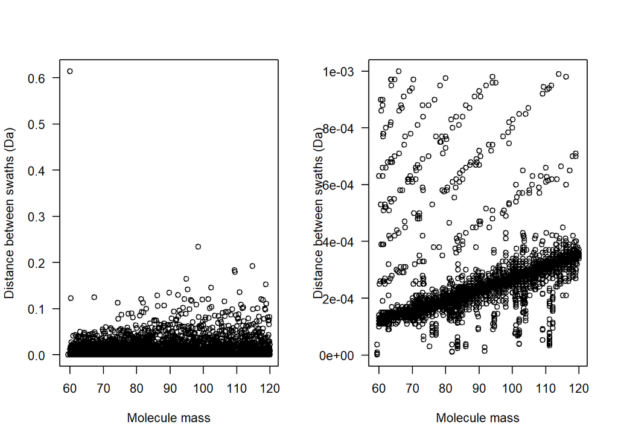

```r
mz_raw <- unlist(mz(simple_data))

segment_size <- 7
lowest_mz <- floor(min(mz_raw))-floor(min(mz_raw))%%segment_size
highest_mz <- floor(max(mz_raw))+floor(max(mz_raw))%%segment_size
bin_minima <- seq(lowest_mz, highest_mz, segment_size)

getMeds <- function(bin_min, mz_raw){
  raw_i <- mz_raw[mz_raw>(bin_min)&mz_raw<(bin_min+segment_size)]
  span <- round(bin_min/segment_size)
  peak_mids <- list()
  for(j in seq(0, segment_size-0.1, 0.1)){
    raw_bin_j <- raw_i[raw_i>(bin_min+j)&raw_i<(bin_min+j+0.1)]
    if(length(raw_bin_j)>1){
      hist_bin_j <- hist(raw_bin_j, breaks = 10000, plot = F)
      peak_idxs <- MALDIquant:::.localMaxima(hist_bin_j$counts, span)
      peak_mids[[(j+0.1)*10]] <- hist_bin_j$mids[peak_idxs]
    }
  }
  return(peak_mids)
}

mids <- unlist(lapply(bin_minima, getMeds, mz_raw))

fit_df <- data.frame(mass=mids[-1], diff_y=diff(mids))
fit_df_smallnums <- filter(fit_df, diff_y<0.001)
layout(matrix(c(1,2,1,2), byrow = T, nrow = 2))
plot(fit_df$mass, fit_df$diff_y, las=1,
     ylab="Distance between swaths (Da)", xlab="Molecule mass")
plot(fit_df_smallnums$mass, fit_df_smallnums$diff_y, las=1,
     ylab="Distance between swaths (Da)", xlab="Molecule mass")
```

This plot is more or less exactly what we expected. Remember, we’re looking for a positive correlation between molecular mass and distance between swaths.

The left plot shows the raw differences between swaths, but this is hard to see patterns in because a few outliers throw the y-axis out of whack. On the right, I’ve zoomed in to just swath differences less than 0.001 Da - still showing ~95% of the data. Here, we can see the trends that we were looking for. The thick line along the bottom is the “true” signal, the typical distance between swaths. The fainter upper trends occur when a peak is missing in the data - for example, in regions where molecules themselves are few and far between. These show the same trend as the actual data, but have a slope double, triple, etc. the base signal as one, two, or more peaks are absent.

What we’d like to do is eliminate the false signal here and run a linear regression on the true data points. I’m going to do this semi-manually by fitting quadratic equations to three points along the curve, then calculating the coefficients via some linear algebra magic.

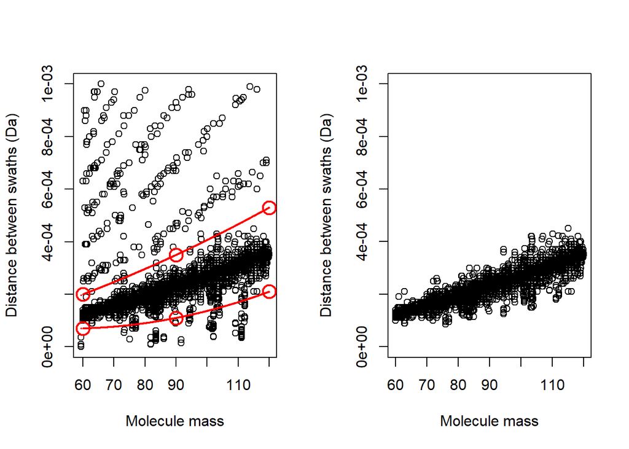

```r
curveMaker <- function(x, formula){formula[1]*x**2+formula[2]*x+formula[3]}

test_points <- data.frame(x=c(60, 90, 120),
                           y_upper=c(0.00020, 0.00035, 0.00053),
                           y_lower=c(0.00007, 0.00011, 0.00021))

form_mat <- rbind(c(test_points$x[1]**2, test_points$x[1], 1),
                 c(test_points$x[2]**2, test_points$x[2], 1),
                 c(test_points$x[3]**2, test_points$x[3], 1))
upper_formula <- solve(form_mat, test_points$y_upper)
upper_bound <- curveMaker(fit_df_smallnums$mass, upper_formula)
lower_formula <- solve(form_mat, test_points$y_lower)
lower_bound <- curveMaker(fit_df_smallnums$mass, lower_formula)

par(mfrow=c(1,2))

plot(fit_df_smallnums$mass, fit_df_smallnums$diff_y,
     ylab="Distance between swaths (Da)", xlab="Molecule mass")
points(test_points$x, test_points$y_upper, col="red", lwd=2, cex=2)
points(test_points$x, test_points$y_lower, col="red", lwd=2, cex=2)
points(fit_df_smallnums$mass, upper_bound, col="red", cex=0.2)
points(fit_df_smallnums$mass, lower_bound, col="red", cex=0.2)

good_vals <- filter(fit_df_smallnums, diff_y<upper_bound&diff_y>lower_bound)
plot(good_vals, ylim=c(0, 0.001),
     ylab="Distance between swaths (Da)", xlab="Molecule mass")
```

We probably could fit the model a lot tighter and remove more noise, but that’s what the linear model is designed to do - all that we were hoping to accomplish with this step was removing the signal from the missing peak differences.

Now let’s fit the linear model to our pretty data. The question here, as with all non-linear models, is how to balance between overfitting and accuracy. AIC’s do a reasonable job of estimating this, but I’m not even sure the curve is polynomic - rather, it could quite easily be exponential, which is more what I’d expect given the data itself. I’m thinking a feedback loop (i.e. exponential) is more likely than the data itself curving in a polynomic way.

Additionally, we should decide whether to fit the model through zero. There are [arguments against this](https://dynamicecology.wordpress.com/2017/04/13/dont-force-your-regression-through-zero-just-because-you-know-the-true-intercept-has-to-be-zero/), basically pointing out that if your model doesn’t go through zero automatically, you should beware of non-linear effects near zero where the signal itself breaks down.

So we’ve got three models to try initially: polynomial, polynomial with fixed intercept, and exponential. Data below!

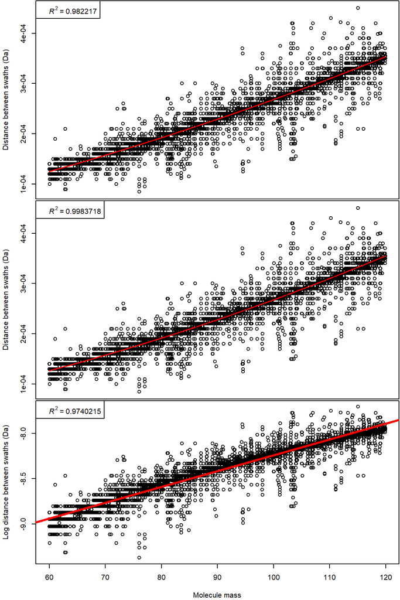

```r
par(mfrow=c(3,1))
par(mar=c(0.1, 4.1, 0.1, 0.1))

#Polynomial
model <- lm(good_vals$diff_y~poly(good_vals$mass, 2, raw = T))
coefs <- model$coefficients
np_vals <- sapply(good_vals$mass, function(x){coefs[3]*x**2+coefs[2]*x+coefs[1]})
plot(good_vals,
     ylab="Distance between swaths (Da)", xlab="", xaxt="n")
points(good_vals$mass, np_vals, col="red", pch=19, cex=0.2)
legend("topleft", legend = bquote(italic("R")^2 ~ "=" ~ .(summary(model)$r.squared)))

#Polynomial with fixed intercept
model <- lm(good_vals$diff_y~0+poly(good_vals$mass, 2, raw = T))
coefs <- model$coefficients
np_vals <- sapply(good_vals$mass, function(x){coefs[2]*x**2+coefs[1]*x})
plot(good_vals,
     ylab="Distance between swaths (Da)", xlab="", xaxt="n")
points(good_vals$mass, np_vals, col="red", pch=19, cex=0.2)
legend("topleft", legend = bquote(italic("R")^2 ~ "=" ~ .(summary(model)$r.squared)))

par(mar=c(4.1, 4.1, 0.1, 0.1))
# Exponential
model <- lm(log(good_vals$diff_y)~good_vals$mass)
plot(log(good_vals$diff_y)~good_vals$mass,
     ylab="Log distance between swaths (Da)", xlab="Molecule mass")
abline(model, col="red", lwd=3)
legend("topleft", legend = bquote(italic("R")^2 ~ "=" ~ .(summary(model)$r.squared)))
```

The quadratic model fit through zero appears to be the best fit, but I’m wary of the fixed at zero term and the interpretation of the $R^2$ without an intercept.

What this equation tells us is, given a mass, how wide we can expect its swath to be. So we need to recursively calculate the masses of each possible bin, acknowledging that they increase in size and that the width of each is entirely dependent on the mass calculated before. We also need to identify a start value from which to begin predicting bins.

Let’s compare how well our mid-prediction function works to the actual, identified swaths found above:

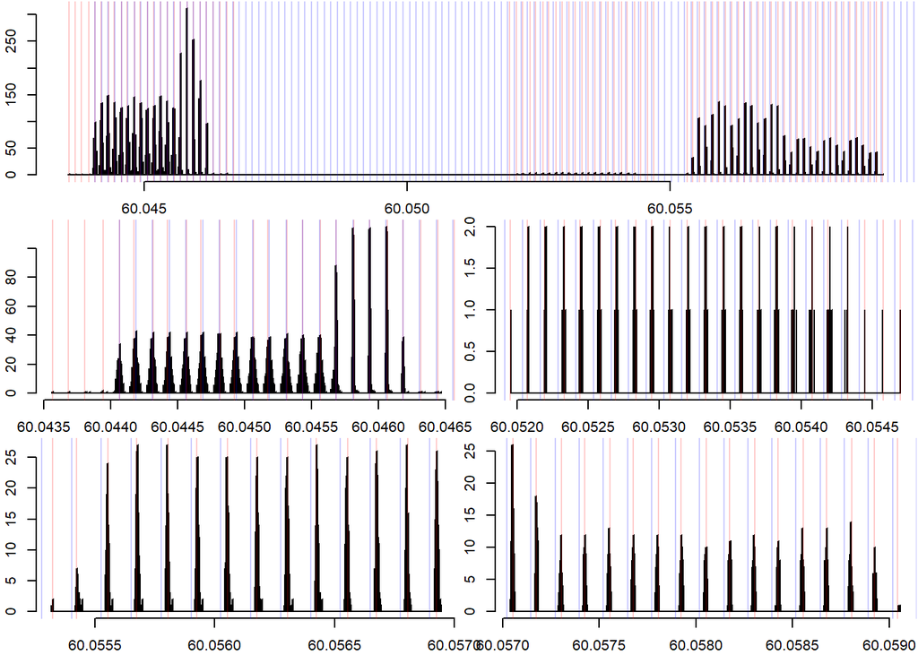

```r
bestfit_formula_maker <- function(model){
  if(model=="quad"){
    coefs <- lm(good_vals$diff_y~poly(good_vals$mass, 2, raw = T))$coefficients
    return(function(x){as.numeric(coefs[3]*x**2+coefs[2]*x+coefs[1])})
  } else if(model=="quad0") {
    coefs <- lm(good_vals$diff_y~poly(good_vals$mass, 2, raw = T)+0)$coefficients
    return(function(x){as.numeric(coefs[2]*x**2+coefs[1]*x)})
  } else if(model=="exp"){
    coefs <- lm(log(good_vals$diff_y)~good_vals$mass)$coefficients
    return(function(x){exp(coefs[2]*x)+exp(coefs[1])}) # Currently broken?
  }
}

midsPredictor <- bestfit_formula_maker("quad")
value <- 60.044065
pred_mids <- list(value)
while(value < max(simple_data@assayData$F1.S001@mz)){
  new_value <- value+midsPredictor(value)
  pred_mids[[length(pred_mids)+1]] <- new_value
  value <- new_value
}
pred_mids <- unlist(pred_mids)

layout(mat = matrix(c(1,1,2,3,4,5), byrow = T, ncol = 2))
par(mar=c(2.1, 2.1, 0.1, 0.1))

for(tuple in list(c(60.04, 60.06), c(60.0435, 60.0465), c(60.0518, 60.055),
                  c(60.055, 60.057), c(60.057, 60.06))){
  hist(mz_raw[mz_raw>tuple[1]&mz_raw<tuple[2]], breaks = 1000, main="", xlab="", ylab="")
  abline(v=mids, col=rgb(1,0,0,0.2))
  abline(v=pred_mids, col=rgb(0,0,1,0.2))
}
```

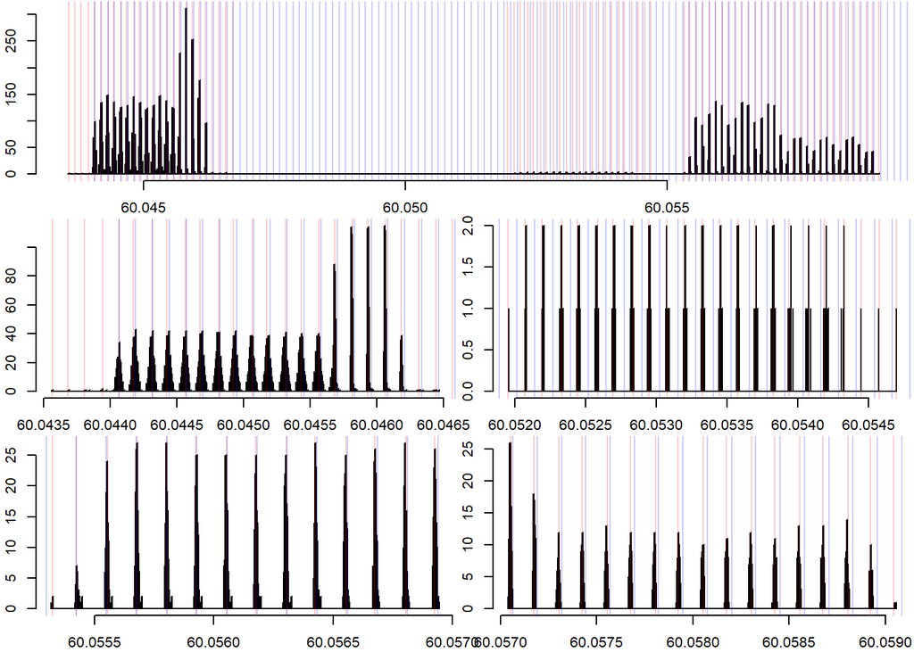

```r
midsPredictor <- bestfit_formula_maker("quad0")
value <- 60.044065
pred_mids <- list(value)
while(value < max(simple_data@assayData$F1.S001@mz)){
  new_value <- value+midsPredictor(value)
  pred_mids[[length(pred_mids)+1]] <- new_value
  value <- new_value
}
pred_mids <- unlist(pred_mids)

layout(mat = matrix(c(1,1,2,3,4,5), byrow = T, ncol = 2))
par(mar=c(2.1, 2.1, 0.1, 0.1))

for(tuple in list(c(60.04, 60.06), c(60.0435, 60.0465), c(60.0518, 60.055),
                  c(60.055, 60.057), c(60.057, 60.06))){
  hist(mz_raw[mz_raw>tuple[1]&mz_raw<tuple[2]], breaks = 1000, main="", xlab="", ylab="")
  abline(v=mids, col=rgb(1,0,0,0.2))
  abline(v=pred_mids, col=rgb(0,0,1,0.2))
}
```

In the example above, I’m using the first peak in the left graph as the start value for the prediction function (i.e. a mass of 60.044065). The red lines are at manually-determined (okay, not manually, using the local maximum algorithm) peaks and the blue lines show where the linear model predicts that we’d find peaks. The red lines are only found where we have data, but we’d like to create swaths across *all* areas, in case future files have data where there isn’t any in the calibration file.

The prediction does an excellent job of predicting the peaks within a group of swaths, but immediately breaks down when it attemps to predict “across the gap” and is significantly off when applied to the next group.

I’m assuming this is because the mass-spec doesn’t actually collect the swaths in a regular fashion. Instead, it has some way of noticing when there’s ions (even if those ions are at zero intensity?) and measuring them. Or perhaps it re-calibrates where it’s collecting swaths (i.e. where the bins are) whenever it runs into an empty area.

Either way, this is pretty much a death knell for this particular project. In order to have rectangular data across files, there must be a way of properly predicting where the m/z values will be collected. Whether because the model doesn’t fit the data perfectly or because the data itself isn’t collected in a regular fashion, there doesn’t seem to be a way to predict swaths algorithmically across peak groups, let alone different files.